# DC Prelim Data

Adam R

November 3, 2018

# Notes

## Notes from August 2018 PARCC Presentation

- PARCC scores in DC up for 3rd year in a row across ELA and Math. 33.3% passing in ELA and 29.4% passing in Math.

## Notes from http://dcpsbudget.ourdcschools.org/

- While individual school budgets account for roughly 85% of total educational expenditures in the DCPS school system, they do not cover everything. Central office, textbooks, athletics, special education related services other than psychologists and social workers, utilities, security, food service, and maintenance all fall outside individual school budgets and so are not shown above.
- The result is that per pupil allocations for general education vary widely from school to school with variable correlation to enrollment.
- The at-risk allocation is based on the number of students that are at-risk of academic failure based on one or more of the following: homeless, in the District’s foster care system, receiving Temporary Assistance for Needy Families (TANF) or the Supplemental Nutrition Assistance Program (SNAP), or in high school only, are at least one year older than the expected age for their grade. According to DC law, at-risk funds are supposed to follow the student to his or her school.

## Notes from https://dcps.dc.gov/node/966292

- Total # of schools is 116

# Summary Stats

## Enrollment

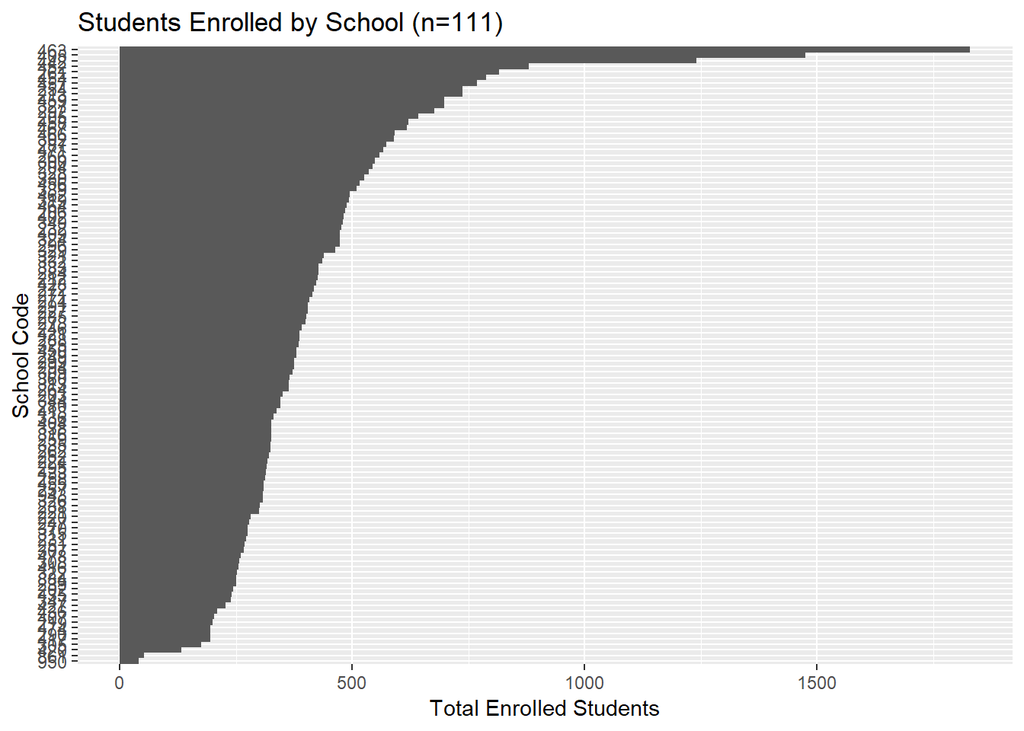

```r
ggplot(dc) + geom_col(width=1,aes(x=reorder(as.factor(`School Code`),`Total Enrolled`), y=`Total Enrolled`)) + coord_flip() + xlab("School Code") + ylab("Total Enrolled Students") + labs(title="Students Enrolled by School (n=111)")
```

```r
summary(dc$`Total Enrolled`)
```

```
##    Min. 1st Qu.  Median    Mean 3rd Qu.    Max.
##    40.0   300.5   379.0   428.4   490.5  1829.0
```

## PARCC Results

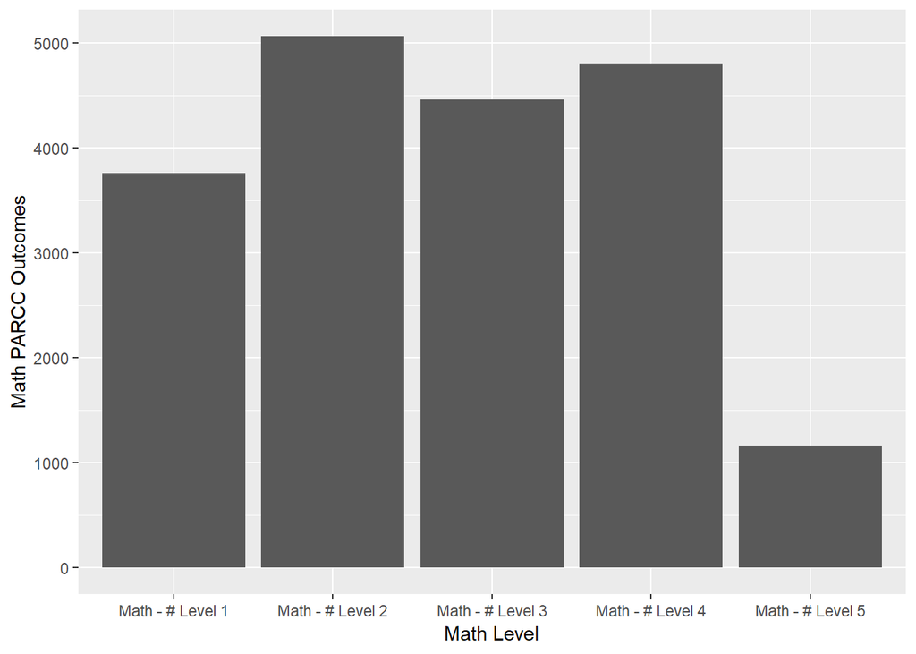

```r
dc_math <- dc %>% gather(key=`Math Level`, value=`Math PARCC Outcomes`, `Math - # Level 1`, `Math - # Level 2`, `Math - # Level 3`, `Math - # Level 4`, `Math - # Level 4`, `Math - # Level 5`) %>% select(`Math Level`, `Math PARCC Outcomes`)

ggplot(dc_math) + geom_col(aes(x=`Math Level`, y=`Math PARCC Outcomes`))
```

## PARCC Results by Ward

```
## # A tibble: 8 x 4
##   Dir_Ward `ELA Test Takers` `ELA Proficient` `% ELA Proficient`
##      <int>             <int>            <int> <chr>
## 1        8              2871              333 11.6%
## 2        7              2132              276 12.9%
## 3        5              1503              338 22.5%
## 4        1              1887              582 30.8%
## 5        4              3197             1032 32.3%
## 6        6              2975             1082 36.4%
## 7        2              1245              662 53.2%
## 8        3              3641             2630 72.2%
```

```
## # A tibble: 8 x 4
##   Dir_Ward `Math Test Takers` `Math Proficient` `% Math Proficient`
##      <int>              <int>             <int> <chr>
## 1        8               2885               303 10.5%
## 2        7               2124               238 11.2%
## 3        5               1502               179 11.9%
## 4        6               2953               868 29.4%
## 5        1               1840               562 30.5%
## 6        4               3191               987 30.9%
## 7        2               1219               546 44.8%
## 8        3               3546              2287 64.5%
```

# Math Test Results by School Uniform

```r
dc %>% count(Uniform)
```

```
## # A tibble: 2 x 2
##   Uniform     n
##   <fct>   <int>
## 1 no         26
## 2 yes        85
```

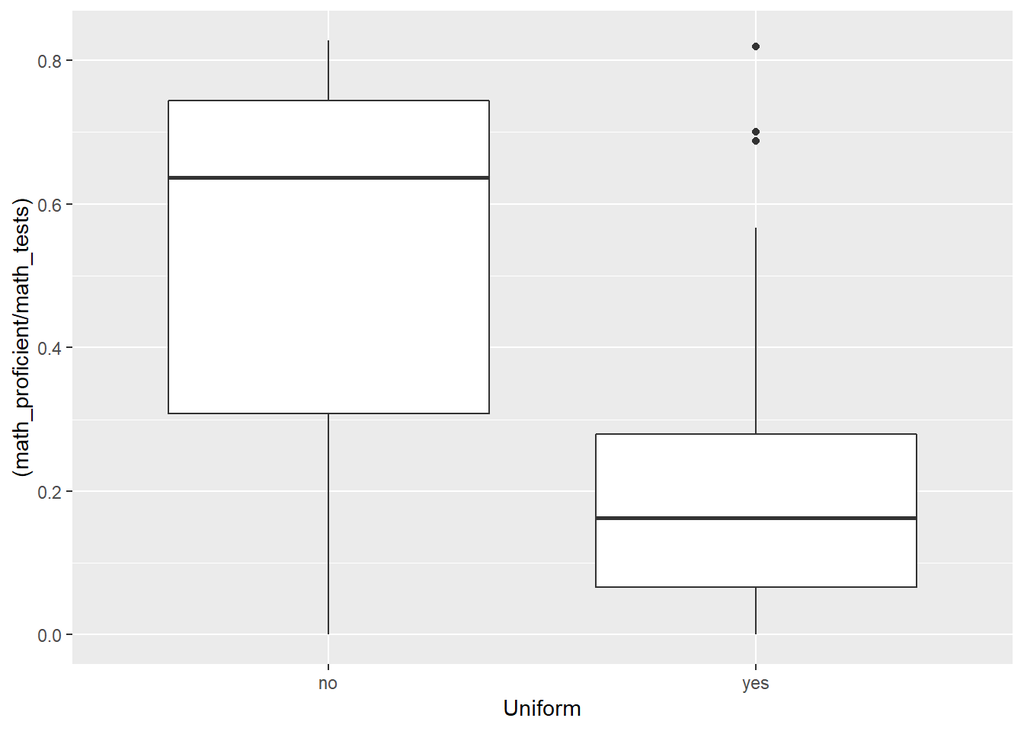

```r
  ggplot(dc) + geom_boxplot(aes(x = Uniform, y=  (math_proficient/math_tests)))
```

# Math Test Performance by Truancy Rate

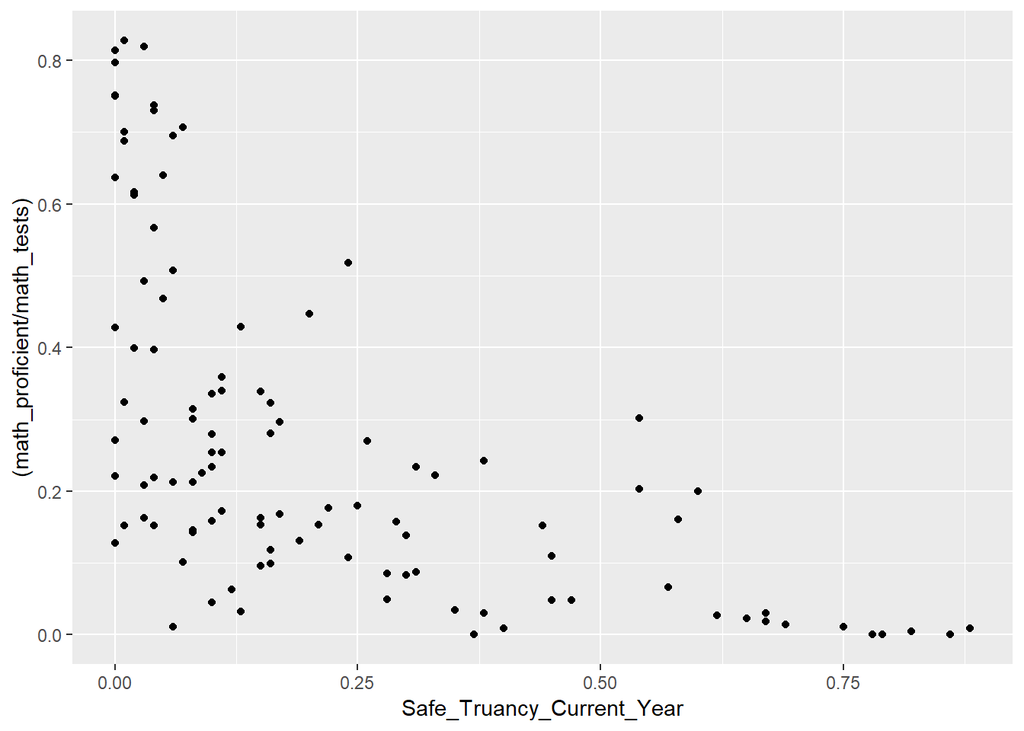

```r
ggplot(dc) + geom_point(aes(x = Safe_Truancy_Current_Year, y = (math_proficient/math_tests)))
```